# Introduction to the sf Package

Jamie Afflerbach

# Background

From the [**sf**](https://r-spatial.github.io/sf/articles/sf1.html) vignette:

> Simple features or simple feature access refers to a formal standard (ISO 19125-1:2004) that describes how objects in the real world can be represented in computers, with emphasis on the spatial geometry of these objects. It also describes how such objects can be stored in and retrieved from databases, and which geometrical operations should be defined for them.

> The standard is widely implemented in spatial databases (such as PostGIS), commercial GIS (e.g., ESRI ArcGIS) and forms the vector data basis for libraries such as GDAL. A subset of simple features forms the GeoJSON standard.

> R has well-supported classes for storing spatial data (sp) and interfacing to the above mentioned environments (rgdal, rgeos), but has so far lacked a complete implementation of simple features, making conversions at times convoluted, inefficient or incomplete. The package sf tries to fill this gap, and aims at succeeding sp in the long term.

The **sf** package is an R implementation of [Simple Features](https://en.wikipedia.org/wiki/Simple_Features). This package incorporates:

- a new spatial data class system in R
- functions for reading and writing data
- tools for spatial operations on vectors

Most of the functions in this package starts with prefix `st_` which stands for *spatial* and *temporal*.

# Reading a shapefile

If you’ve used `readOGR()` from the `rgdal` package, you’ll notice the similarities in arguments for the `st_read()` function. We’ll do a quick comparison of the two functions here.

Read in a shapefile of the US West Coast using `readOGR()` from the `rgdal` package, and `st_read` from the `sf` package.

- `dsn` is the path name
- `layer` is the name of the file

*NOTE: you do not need to add an extension to the layer name*

```r
## Read in shapefile using rgdal

system.time(west_shp_rgdal <- readOGR(dsn="shapefiles", layer="wc_regions"))
```

```
##    user  system elapsed
##   0.236   0.004   0.242
```

```r
object.size(west_shp_rgdal)
```

```
## 1142592 bytes
```

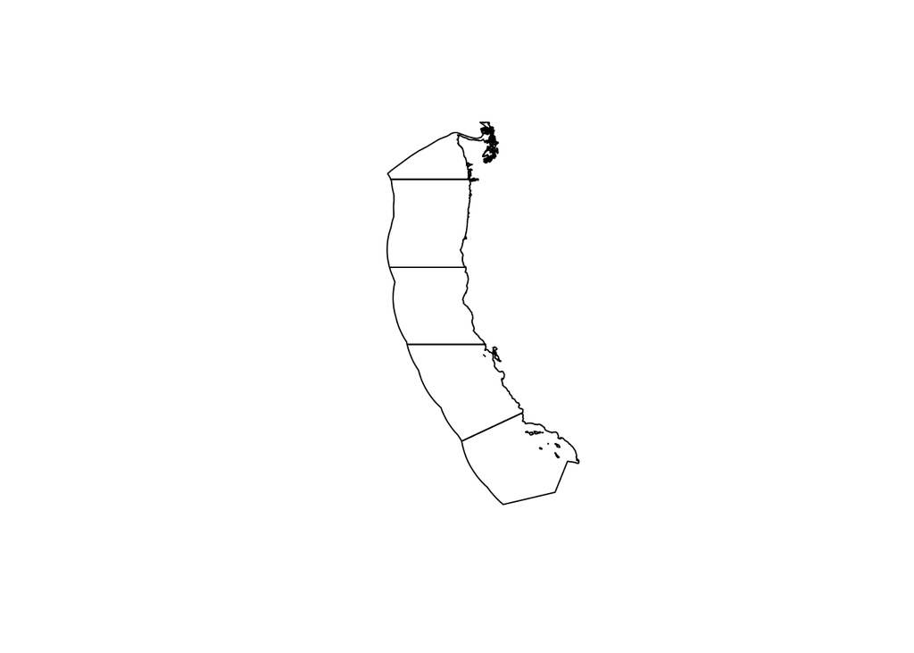

```r
plot(west_shp_rgdal)
```

```r
## Read in shapefile using sf
system.time(west_shp_sf <- st_read(dsn = "shapefiles", layer="wc_regions"))
```

```
##    user  system elapsed
##   0.032   0.000   0.035
```

```r
object.size(west_shp_sf)
```

```
## 887712 bytes
```

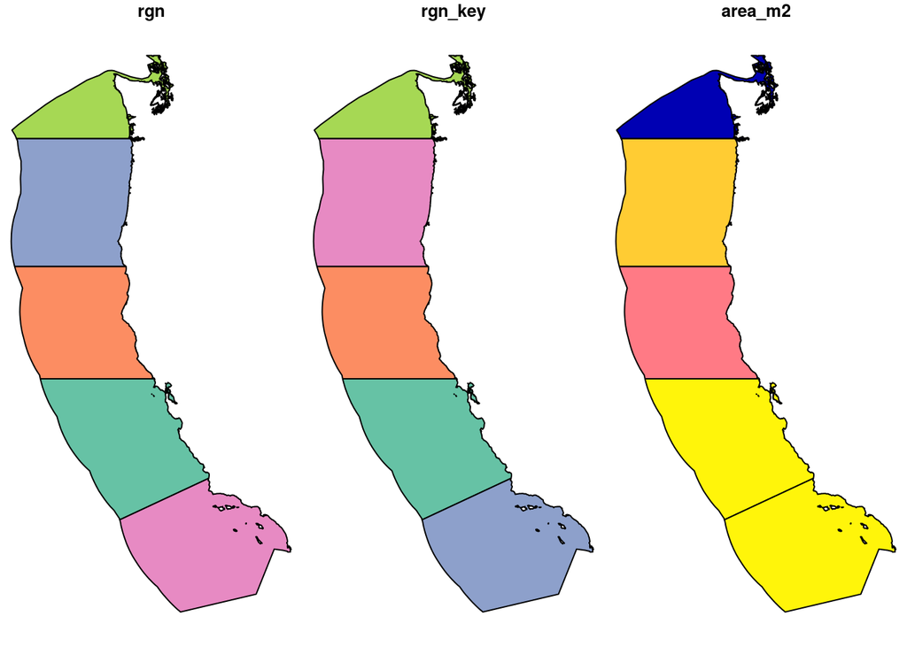

```r
plot(west_shp_sf)
```

You’ll notice right away that these two objects are being plotted differently. This is because these two objects are of different types.

**sf** objects usually have two classes - `sf` and `data.frame`. Two main differences comparing to a regular `data.frame` object are spatial metadata (`geometry type`, `dimension`, `bbox`, `epsg (SRID)`, `proj4string`) and additional column - typically named `geom` or `geometry`.

```r
class(west_shp_sf)
```

```
## [1] "sf"         "data.frame"
```

# Attributes

**sf** objects can be used as a regular `data.frame` object in many operations

```r
west_shp_sf
```

```
## Simple feature collection with 5 features and 3 fields
## geometry type:  MULTIPOLYGON
## dimension:      XY
## bbox:           xmin: -129.1635 ymin: 30.542 xmax: -117.097 ymax: 49.00031
## epsg (SRID):    4326
## proj4string:    +proj=longlat +datum=WGS84 +no_defs
##                   rgn rgn_key      area_m2                       geometry
## 1              Oregon      OR 179994061293 MULTIPOLYGON (((-123.431802...
## 2 Northern California    CA-N 164378809215 MULTIPOLYGON (((-124.210198...
## 3  Central California    CA-C 202738329147 MULTIPOLYGON (((-122.992838...
## 4 Southern California    CA-S 206860777840 MULTIPOLYGON (((-120.650464...
## 5          Washington      WA  66898309678 MULTIPOLYGON (((-122.767494...
```

```r
nrow(west_shp_sf)
```

```
## [1] 5
```

```r
ncol(west_shp_sf)
```

```
## [1] 4
```

## sf & dplyr

It also easy to use the **dplyr** package on `sf` objects:

`select()`

```r
west_shp_sf %>%
  select(rgn, rgn_key, geometry)
```

```
## Simple feature collection with 5 features and 2 fields
## geometry type:  MULTIPOLYGON
## dimension:      XY
## bbox:           xmin: -129.1635 ymin: 30.542 xmax: -117.097 ymax: 49.00031
## epsg (SRID):    4326
## proj4string:    +proj=longlat +datum=WGS84 +no_defs
##                   rgn rgn_key                       geometry
## 1              Oregon      OR MULTIPOLYGON (((-123.431802...
## 2 Northern California    CA-N MULTIPOLYGON (((-124.210198...
## 3  Central California    CA-C MULTIPOLYGON (((-122.992838...
## 4 Southern California    CA-S MULTIPOLYGON (((-120.650464...
## 5          Washington      WA MULTIPOLYGON (((-122.767494...
```

`filter()`

```r
west_shp_sf %>%
  filter(rgn == "Oregon")
```

```
## Simple feature collection with 1 feature and 3 fields
## geometry type:  MULTIPOLYGON
## dimension:      XY
## bbox:           xmin: -129.1635 ymin: 41.9984 xmax: -123.4318 ymax: 46.271
## epsg (SRID):    4326
## proj4string:    +proj=longlat +datum=WGS84 +no_defs
##      rgn rgn_key      area_m2                       geometry
## 1 Oregon      OR 179994061293 MULTIPOLYGON (((-123.431802...
```

`mutate()`

```r
sf_out <- west_shp_sf %>%
  mutate(rgn_id = c(1:5),
         area_km2 = area_m2/1000000) #converting square meters to square kilometers

sf_out
```

```
## Simple feature collection with 5 features and 5 fields
## geometry type:  MULTIPOLYGON
## dimension:      XY
## bbox:           xmin: -129.1635 ymin: 30.542 xmax: -117.097 ymax: 49.00031
## epsg (SRID):    4326
## proj4string:    +proj=longlat +datum=WGS84 +no_defs
##                   rgn rgn_key      area_m2 rgn_id  area_km2
## 1              Oregon      OR 179994061293      1 179994.06
## 2 Northern California    CA-N 164378809215      2 164378.81
## 3  Central California    CA-C 202738329147      3 202738.33
## 4 Southern California    CA-S 206860777840      4 206860.78
## 5          Washington      WA  66898309678      5  66898.31
##                         geometry
## 1 MULTIPOLYGON (((-123.431802...
## 2 MULTIPOLYGON (((-124.210198...
## 3 MULTIPOLYGON (((-122.992838...
## 4 MULTIPOLYGON (((-120.650464...
## 5 MULTIPOLYGON (((-122.767494...
```

## Reprojection

- The `st_transform()` can be used to transform coordinates

```r
sf <- st_transform(sf_out, crs = '+proj=moll +ellps=WGS84') #reprojecting to a mollweide CRS
sf
```

```
## Simple feature collection with 5 features and 5 fields
## geometry type:  MULTIPOLYGON
## dimension:      XY
## bbox:           xmin: -11185430 ymin: 3707232 xmax: -9458705 ymax: 5768385
## epsg (SRID):    NA
## proj4string:    +proj=moll +lon_0=0 +x_0=0 +y_0=0 +ellps=WGS84 +units=m +no_defs
##                   rgn rgn_key      area_m2 rgn_id  area_km2
## 1              Oregon      OR 179994061293      1 179994.06
## 2 Northern California    CA-N 164378809215      2 164378.81
## 3  Central California    CA-C 202738329147      3 202738.33
## 4 Southern California    CA-S 206860777840      4 206860.78
## 5          Washington      WA  66898309678      5  66898.31
##                         geometry
## 1 MULTIPOLYGON (((-9832708.93...
## 2 MULTIPOLYGON (((-10350468.0...
## 3 MULTIPOLYGON (((-10606290.4...
## 4 MULTIPOLYGON (((-10686759.8...
## 5 MULTIPOLYGON (((-9459207.02...
```

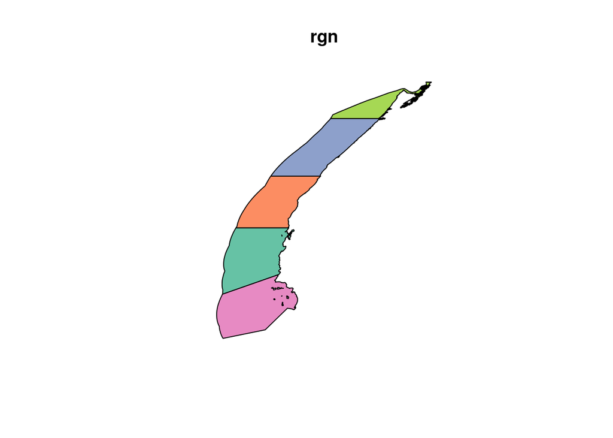

```r
plot(sf[1])
```

# Save

Save the spatial object to disk using `st_write()` and specifying the filename as well as the [driver](http://www.gdal.org/ogr_formats.html).

```r
st_write(sf_out, "shapefiles/wc_regions_clean.shp", driver = "ESRI Shapefile", delete_layer = TRUE)
```

```
## Deleting layer `wc_regions_clean' using driver `ESRI Shapefile'
## Writing layer `wc_regions_clean' to data source `/home/afflerbach/github/spatial-analysis-R/shapefiles/wc_regions_clean.shp' using driver `ESRI Shapefile'
## features:       5
## fields:         5
## geometry type:  Multi Polygon
```

# Visualize with ggplot

`ggplot2` now has integrated functionality to plot sf objects using `geom_sf()`.

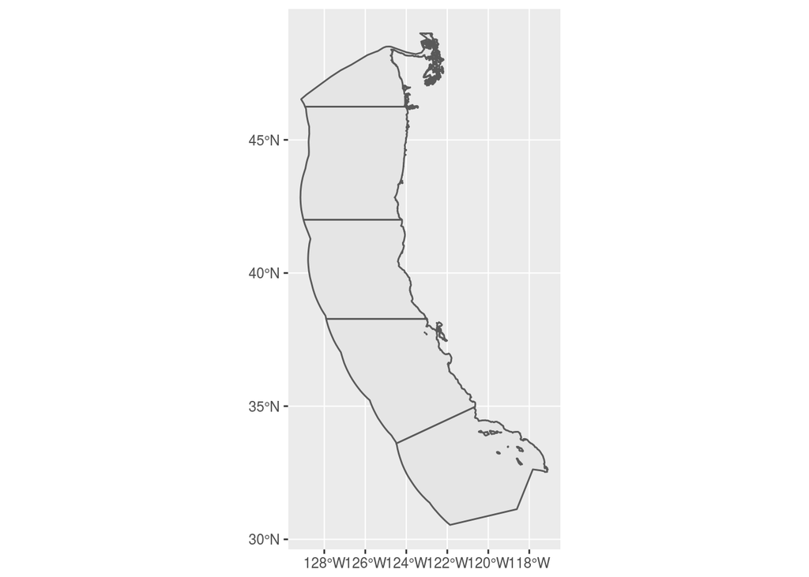

```r
#simplest plot
ggplot(sf_out) +
  geom_sf()
```

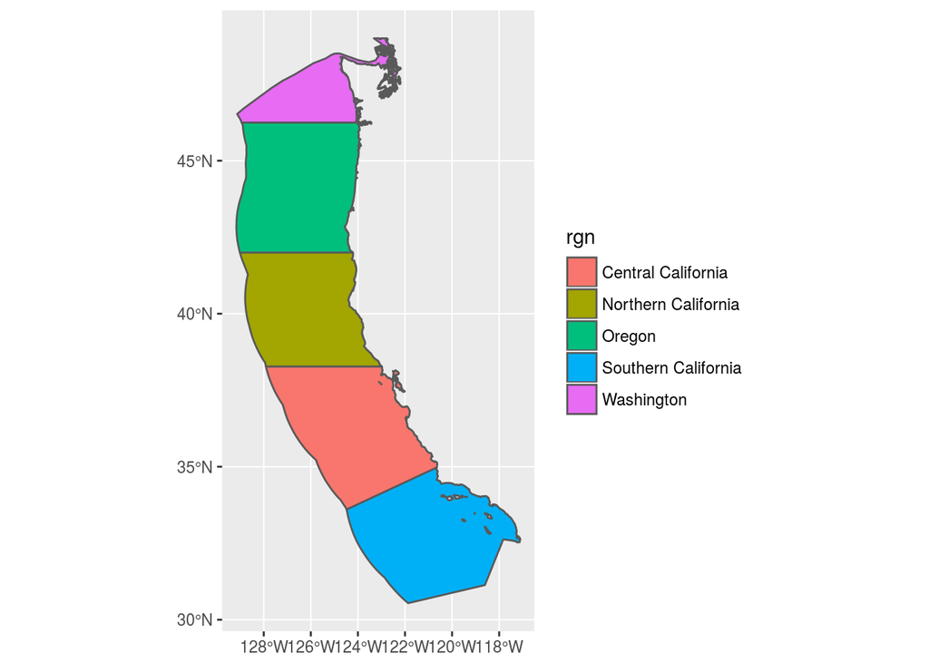

```r
ggplot(sf_out) +
  geom_sf(aes(fill = rgn))
```

We can clean it up a bit, applying a cleaner theme and assigning a Spectral color palette.

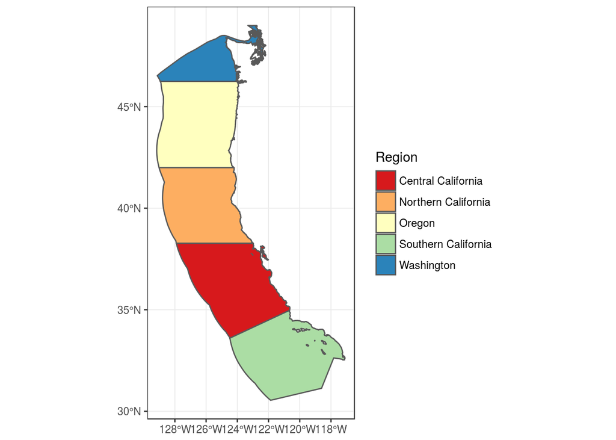

```r
ggplot(sf_out) +
  geom_sf(aes(fill = rgn)) +
  theme_bw() +
  labs(fill = "Region") +
  scale_fill_brewer(palette = "Spectral")
```

This might not be as useful, but you can imagine a use case for continuous values, whether with a spatial object with more polygons or different data types.

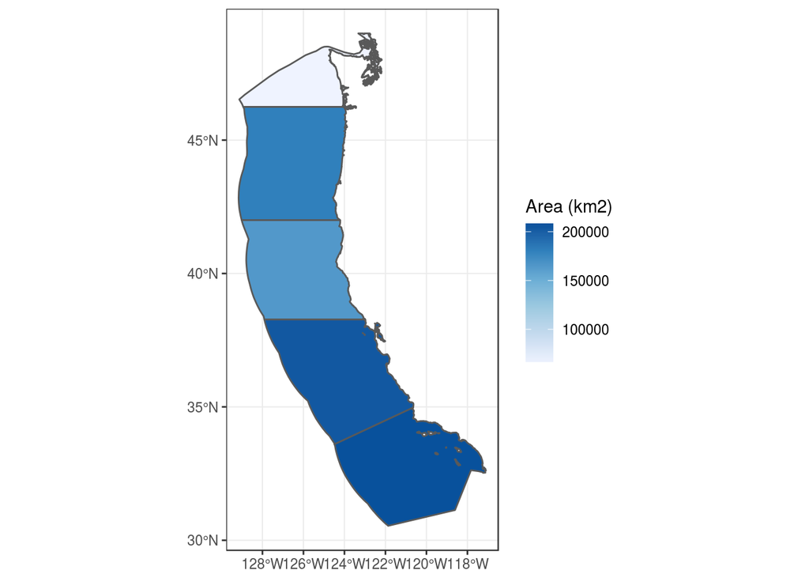

```r
ggplot(sf_out) +
  geom_sf(aes(fill = area_km2)) +
  theme_bw() +
  labs(fill = "Area (km2)") +
  scale_fill_distiller(palette = "Blues", direction=1) #direction can be used to reverse the color palette scale
```

# Union

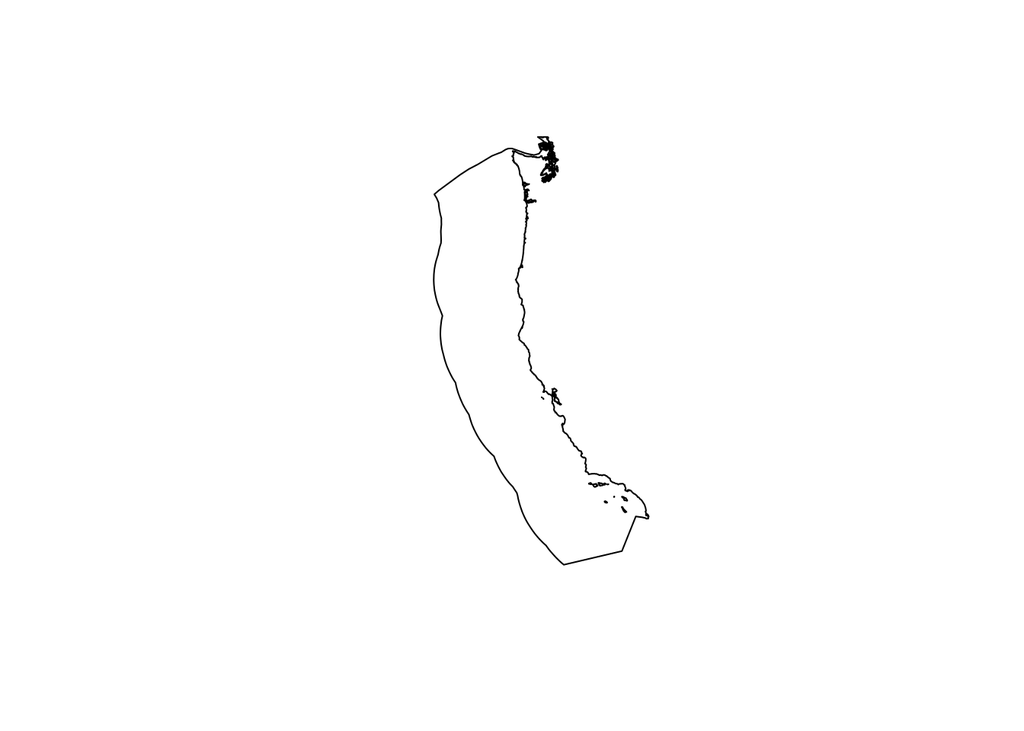

```r
full_rgn  <- st_union(sf_out)

plot(full_rgn)
```

```r
#try plotting with ggplot2

 # ggplot(full_rgn) +
 #   geom_sf()
```

This doesn’t work because now the object is a single geometry object of class `sfc` which is not a data.frame that ggplot requires for plotting. To turn an `sfc` object back into an `sf` object use `st_sf()`.

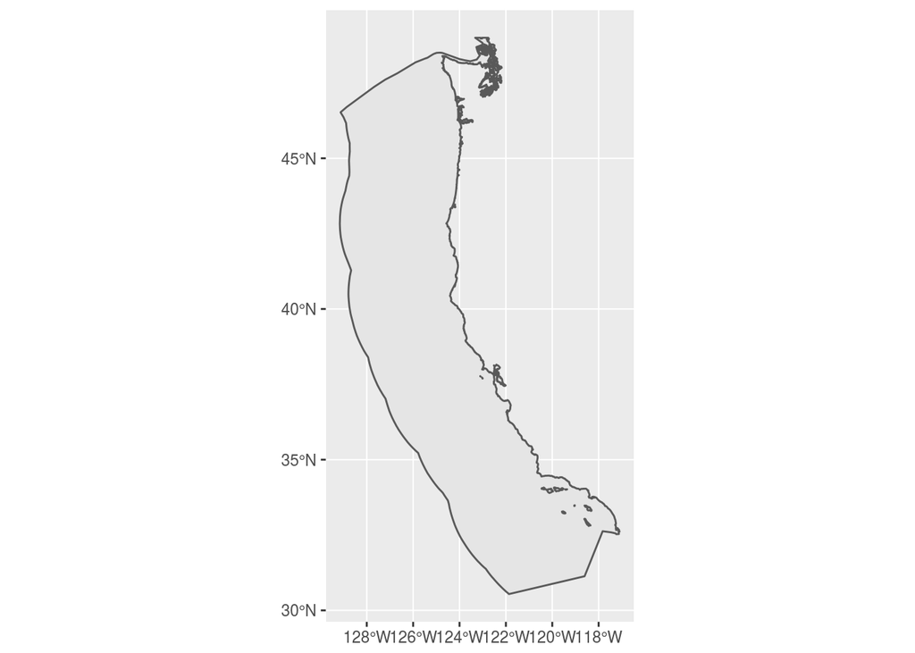

```r
full_rgn <- st_union(sf_out) %>%
            st_sf(geometry = .)

 ggplot(full_rgn) +
   geom_sf()
```

There is a lot more functionality to `sf` including the ability to `intersect` polygons, calculate `distance`, create a `buffer`, and more. Here are some more great resources and tutorials for a deeper dive into this great package:

[Spatial analysis in R with the sf package](https://cdn.rawgit.com/rhodyrstats/geospatial_with_sf/bc2b17cf/geospatial_with_sf.html)  
[Intro to Spatial Analysis](https://cdn.rawgit.com/Nowosad/Intro_to_spatial_analysis/05676e29/Intro_to_spatial_analysis.html#1)  
[sf github repo](https://github.com/r-spatial/sf)  
[Tidy spatial data in R: using dplyr, tidyr, and ggplot2 with sf](http://strimas.com/r/tidy-sf/)  
[mapping-fall-foliage-with-sf](https://rud.is/b/2017/09/18/mapping-fall-foliage-with-sf/)